# Average BMI Among Lower-Income Adults, 1999-2023

Briefing for the community health board

Lucas Poirier

## Why we are looking at this

**Who this is for:** members of the community health board, who are deciding whether to ask staff for a follow-up analysis of weight among lower-income adults.

**Question:** in a classroom copy of NHANES, has average BMI among lower-income adults age 20-80 gone up, gone down, or stayed about the same since 1999-2000?

**Why it matters:** if it has gone up, that is a reason to look more closely, using methods that can describe the whole population.

## What the data show

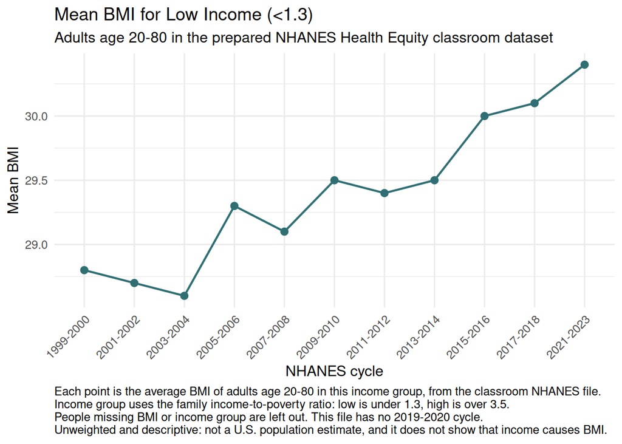

Figure from the Assignment 7 dashboard. The vertical axis starts near 28.5, not 0, so the slope looks steeper than a 1.6-point change. Source: classroom snapshot of CDC/NCHS NHANES public-use data (Centers for Disease Control and Prevention, National Center for Health Statistics 2026).

## The takeaway

In this dataset, **average BMI among lower-income adults went up by about 1.6 points**, from 28.8 in 1999-2000 to 30.4 in 2021-2023. BMI compares weight to height. For someone 5 ft 7 in tall, 1.6 BMI points is roughly 10 pounds.

The other two income groups went up by a similar amount, so this is not only a lower-income pattern:

| Income group | 1999-2000 | 2021-2023 | Change |
| --- | --- | --- | --- |
| Low Income (<1.3) | 28.8 | 30.4 | 1.6 |
| Middle Income | 29.0 | 30.3 | 1.3 |
| High Income (>3.5) | 27.9 | 29.2 | 1.3 |

Average BMI of adults age 20-80 in each group. Every group has at least 1,089 adults in each survey cycle.

## What this cannot tell us

- **Not a U.S. estimate.** These are plain averages of the people in the file. They ignore the NHANES survey weights, so they do not describe all U.S. adults.
- **Not a cause.** The chart shows a change over time. It does not show that income, or anything else, caused it.
- **Some people are left out.** Adults with no recorded BMI or income group are not counted, and the file has no 2019-2020 cycle.

## Suggested next step

Ask staff for a **weighted analysis that uses the NHANES survey design**, with uncertainty ranges, for all three income groups.

That would tell the board whether the rise holds for the U.S. adult population, and whether lower-income adults are actually pulling away from the other groups or just rising with them.

Data: classroom snapshot `nhanes_equity_v6`, prepared from CDC/NCHS NHANES public-use files (Centers for Disease Control and Prevention, National Center for Health Statistics 2026). Unweighted and descriptive. AI assistance (Claude Code) helped draft slide wording. All numbers were checked against the data.

## References

Centers for Disease Control and Prevention, National Center for Health Statistics. 2026. *National Health and Nutrition Examination Survey*. https://wwwn.cdc.gov/nchs/nhanes/.